# L09 Themes

Data Visualization (STAT 302)

INSTRUCTIONS

## Overview

The goal of this lab is to play around with the theme options in `ggplot2`

## Datasets

We’ll be using the `cdc.txt` and `NU_admission_data.csv` datasets.

```r
# load package(s)

# read in the cdc dataset
cdc <- read_delim(file = "data/cdc.txt", delim = "|") %>%
  mutate(
    genhlth = factor(
      genhlth,
      levels = c("excellent", "very good", "good", "fair", "poor"),
      labels = c("Excellent", "Very Good", "Good", "Fair", "Poor")
      )
    )

# read in NU admission data

# set seed
set.seed(2468)

# selecting a random subset of size 100
cdc_small <- cdc %>%
  slice_sample(n = 100)
```

## Exercise 1

Use the `cdc_small` dataset to explore several pre-set `ggthemes`. The code below constructs the familiar scatterplot of `weight` by `height` and stores it in `plot_01`. Display `plot_01` to observe the default theme. **Explore/apply, and display at least 7 other pre-set themes** from the `ggplot2` or `ggthemes` package. Don’t worry about making adjustments to the figures under the new themes. Just get a sense of what the themes are doing to the original figure `plot_01`.

There should be at least 8 plots for this task, `plot_01` is pictured below. Instead of having 8 large plots which hinders making comparisons between themes and takes up a good deal of room, we should try and arrange our plots in a more user friendly way. There are several ways to do this. One strategy would be to use R yaml chunk options such as `fig-width`, `out-width`, `fig-show`, and `layout-ncol`. Another strategy would be to use `patchwork` or `cowplot`. Or you could combine the stratgies to setup the 8 plots together in a user friendly arrangement.

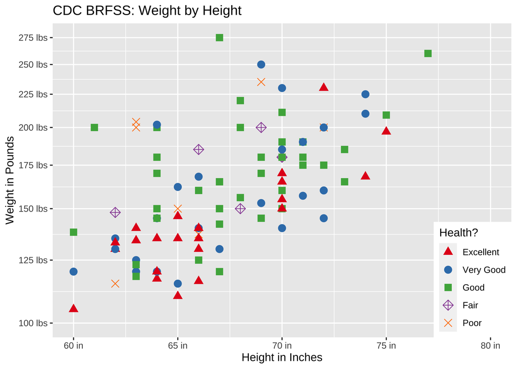

```r
# building plot
plot_01 <- ggplot(
  data = cdc_small,
  aes(x = height, y = weight)
  ) +
  geom_point(size = 3, aes(shape = genhlth, color = genhlth)) +
  scale_y_continuous(
    name = "Weight in Pounds",
    limits = c(100, 275),
    breaks = seq(100, 275, 25),
    trans = "log10",
    labels = scales::label_number(accuracy = 1, suffix = " lbs")
  ) +
  scale_x_continuous(
    name = "Height in Inches",
    limits = c(60, 80),
    breaks = seq(60, 80, 5),
    labels = scales::label_number(accuracy = 1, suffix = " in")
  ) +
  scale_shape_manual(
    name = "Health?",
    labels = c(
      "Excellent", "Very Good",
      "Good", "Fair", "Poor"
    ),
    values = c(17, 19, 15, 9, 4)
  ) +
  scale_color_brewer(
    name = "Health?",
    labels = c(
      "Excellent", "Very Good",
      "Good", "Fair", "Poor"
    ),
    palette = "Set1"
  ) +
  theme(
    legend.position = c(1, 0),
    legend.justification = c(1, 0)
  ) +
  labs(title = "CDC BRFSS: Weight by Height")

plot_01
```

**Important**

**Which theme or themes do you particularly like? Why?**

## Exercise 2

Using `plot_01` from Exercise 1 and the `theme()` function, attempt to construct the ugliest plot possible (example pictured below). Be creative! It should NOT look exactly like the example. Since the goal is to understand a variety of adjustments, you should use a **minimum** of 10 different manual adjustments within `theme()` (this picture uses 17!).

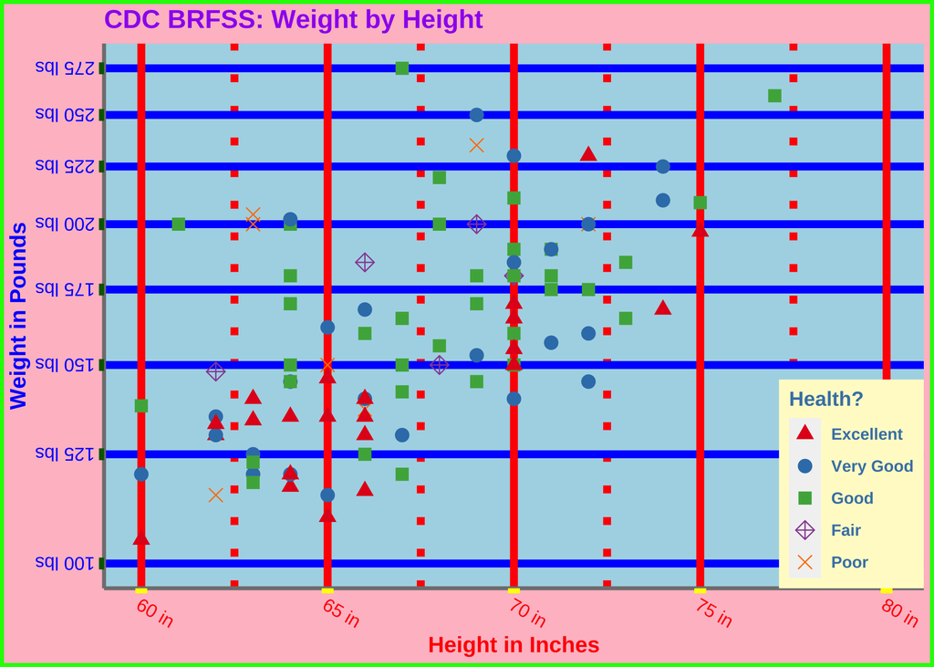

## Exercise 3

We will be making use of your code from Exercise 3 from *L07 Layers*. Using the `NU_admission_data.csv` you created two separate plots derived from the single plot depicted in `undergraduate-admissions-statistics.pdf`. Style these plots so they follow a “Northwestern” theme. You are welcome to display the plots separately OR design a layout that displays both together (likely one stacked above the other).

Check out the following webpages to help create your Northwestern theme:

- [Visual Identity](https://www.northwestern.edu/brand/visual-identity/index.html)
- [Color Palettes](https://www.northwestern.edu/brand/visual-identity/color-palettes/index.html)
- [Fonts & Typography](https://www.northwestern.edu/brand/visual-identity/fonts-typography/index.html) — Need to use [substitute fonts](https://www.northwestern.edu/brand/visual-identity/fonts-typography/substitute-fonts/index.html)

**Additional requirement:**

Use a free non-standard font from google for the title. Pick one that looks similar to a Northwestern font.

**Note**

I find this [blog post](https://cran.rstudio.com/web/packages/showtext/vignettes/introduction.html) to be extremely useful for adding fonts. Important packages for using non-standard fonts are `showtext`, `extrafont`, `extrafontdb`, and `sysfonts`. The last 3 generally just need to be installed (not loaded per session).

## Challenge

**Challenge is optional for all students, but we recommend trying it out!**

Using `cdc_small` dataset, re-create your own version inspired by the plot below.

**Must haves:**

- Use two non-standard fonts (one for labeling the point and the other for the axes)
- Use at least two colors (one for the added point, another for the rest of the points)
- A curved arrow used to label the point

Using Bilbo Baggins’ responses below to the CDC BRSFF questions, add Bilbo’s data point to a scatterplot of `weight` by `height`.

- `genhlth` - How would you rate your general health? **fair**
- `exerany` - Have you exercised in the past month? **1=yes**
- `hlthplan` - Do you have some form of health coverage? **0=no**
- `smoke100` - Have you smoked at least 100 cigarettes in your life time? **1=yes**
- `height` - height in inches: **46**
- `weight` - weight in pounds: **120**
- `wtdesire` - weight desired in pounds: **120**
- `age` - in years: **45**
- `gender` - m for males and f for females: **m**

**Note**

Adding non-standard fonts can be an *adventure*. I find this [blog post](https://cran.rstudio.com/web/packages/showtext/vignettes/introduction.html) to be extremely useful for adding fonts. Important packages for using non-standard fonts are `showtext`, `extrafont`, `extrafontdb`, and `sysfonts`. The last 3 generally just need to be installed (not loaded per session).

*Hint:*

- Create a new dataset (maybe call it `bilbo` or `bilbo_baggins`) using either `data.frame()` (base R - example in book) or `tibble()` (tidyverse - see help documentation for the function). Make sure to use variable names that exactly match `cdc`’s variable names. We have provided the `tidyverse` approach.
- Search google fonts to find some free fonts to use (can get free fonts from other locations)

```r
# build dataset for Bilbo Baggins
bilbo <- tibble(
  genhlth  = "fair",
  exerany  = 1,
  hlthplan = 0,
  smoke100 = 1,
  height   = 46,
  weight   = 120,
  wtdesire = 120,
  age      = 45,
  gender   = "m"
)
```

[figure not shown]